# Data Visualization

# Essentials of ggplot2

The following brief overview is adapted from an [**STHDA tutorial**](http://www.sthda.com/english/wiki/ggplot2-essentials) that covers all the basic types of plots you can make with ggplot.

The concept behind ggplot2 divides plot into **three different fundamental** parts:

**Plot = Data + Aesthetics + Geometry**

The principal elements of every plot can be defined as follows:

- **Data** is a data frame (variables) to be plotted.
- **Aesthetics**: the `aes()` function is used to indicate *how* to display the data:
  - which categories or measurements to map to x and y coordinates; or color, size or shape of points, etc.
- **Geometry** defines the *type of graphics*
  - e.g. histogram, box plot, line plot, density plot, dot plot, etc.

There are **two major functions** in the ggplot2 package:

- `qplot()` stands for quick plot, which can be used to produce easily simple plots.
- `ggplot()` function is more flexible and robust than `qplot()` for building a plot piece by piece.

Plots are constructed by **layering** geometries, additional aesthetics, and themes on top of the primary aesthetic mapping.

The **basic syntax** is:

```r
ggplot(data = <data.frame>,
       mapping = aes(x = <column of data.frame>, y = <column of data.frame>)) +
  geom_<type of geometry>()
```

Notice that as layers are added, a `+` symbol is added at the end of the previous layer. This signals that the plot is not finished.

*The `+` symbol must always appear at the end of a line.*

## Aesthetics

If your data is **tidy**, then the columns of your data frame will contain the variables that you want to display. Let’s take a minute to review tidy data by reviewing the page on the course website.

Remember how we said that R is a **vectorized** language? Vectors are the basic units of all data structures in R.

So, each **column** of a data frame can be **mapped** to different **aesthetics** of the graph (e.g. axis, colors, shapes, etc.). A few of the examples below are based on Chapter 3 from *R for Data Science*.

### Specifying aesthetics

There are **two ways** to specify aesthetics:

- **Mapping**: This maps specific types of **data** to different visual elements
  - Mappings are are always included *inside* of an `aes()` directive.
    - In the **data** layer, mapping is applied to **all geometries**.
    - In the **geom** layer (or other layers), the mapping will be applied only to a particular geometry or feature.
- **Setting**: Manually set an aesthetic **independently** of data
  - Settings are placed *outside* of an `aes()` directive.

Aesthetic elements include things such as:

- x- and y- axes
- Colors
- The size of points (in mm)
- The shape of points (a number; see below)
- Transparency (range 0-1)

## Geometries

**Geometries** control the *type of visual paradigm* you want to use to display your data, for example:

- geom_bar() - barchart
- geom_histogram() - histogram
- geom_dotplot() - dot plot, a.k.a. strip chart
- geom_boxplot() - boxplot
- geom_violin() - violin plot
- geom_point() - scatterplot

Geom functions also allow you to add additional features to a graph, for example:

- geom_jitter() - spread points out (e.g. on strip charts) to make the data more visible
- geom_vline() - add a vertical line (can also add other kinds of lines)

Statistical features can also be layered onto graphs, e.g.:

- geom_smooth() - a regression line (according to a global or local model)
- stat_summary() - add some kind of statistical function to a graph
  - This can also be done by adding `stat = "something"` inside another geometry (some examples below)

### Themes

[**Themes**](https://ggplot2.tidyverse.org/reference/theme.html) are used to customize the **non-data components** of your graphs, such as titles, labels, fonts, background, gridlines, and legends.

- The **default** appearance of ggplot graphs produces graphs with a gray background and white gridlines. This can be changed to almost any look and feel by customizing their themes, which can also be used to give plots a consistent look for presentation.
- The [**ggthemes*](https://yutannihilation.github.io/allYourFigureAreBelongToUs/ggthemes/) package provides a variety of defined themes that replicate the look and feel for different visual paradigms and applications.
- `theme()` components can also be set manually.

## Plotting functions

### The `qplot()` uses simple syntax to generate plots

The “quick plot” method uses simplified syntax resembling that of Base R. The biggest difference is that we explicitly add the **geometry**.

```r
head(iris)
```

```
##   Sepal.Length Sepal.Width Petal.Length Petal.Width Species
## 1          5.1         3.5          1.4         0.2  setosa
## 2          4.9         3.0          1.4         0.2  setosa
## 3          4.7         3.2          1.3         0.2  setosa
## 4          4.6         3.1          1.5         0.2  setosa
## 5          5.0         3.6          1.4         0.2  setosa
## 6          5.4         3.9          1.7         0.4  setosa
```

```r
# ================================================== #
# quick plot with defaults


# ================================================== #
# fancier plot
```

### The `ggplot()` function builds plots layer by layer

Again, you can set a **color** for all points, or by groups (factors) in the dataset.

```r
# ================================================== #
# global aes mapping by factor group


# ================================================== #
# mapping to data to aes can also go inside a geometry


# ================================================== #
# manual mapping of ALL data to the same color

# can do this globally ...


# ... or in the geom layer
```

# Histograms

Histograms are good for showing the **distribution** of a **single quantitative variable**. Two or more distributions can be shown together on one histogram, though showing more than two or three gets really confusing.

## `hist()` in base R

Base R has a special function called `hist()`. It’s great for very quick visualization.

Plot labels can get kind of ugly, so it’s nice to add labels if you’re going to share your plots with someone else.

```r
# do it in steps


# ================================================== #
# do it in one go


# prettier
```

## qplot() and geom_histogram() in ggplot2

# Bar plots: comparing 1D categorical data

Bar plots are among the most common plots and are useful for comparing counts among individuals or groups.

## barplot() in base R

Base R has a built-in function `barplot()`.

- The first argument to `barplot()` is `height`, which is expected to be a vector or a matrix.
- The arrangement of bars is given by the `beside` argument, which is `FALSE` by default.
- If `height` is a matrix, the default setting makes a **stacked** barplot.
- Set `beside=TRUE` to make a **side-by-side** barplot.

Again, there are a bunch of parameters that can be used to control other aspects of the plot’s appearance.

Let’s make a barplot for a toy dataset where we compare gene expression levels for five different *Arabidopsis* genes under different nutrient conditions.

```r
# ================================================== #
# create sample data


# ================================================== #
# genes in Control condition (a single vector)


# ================================================== #
# matrix with stacked bars


# ================================================== #
# side-by-side bars in the rainbow palette, horizontal orientation
```

## `geom_bar()` in ggplot2

To make a barplot grouped by **Condition** in ggplot2, we will need to transform `sampleData.df` into a different format. Let’s review what **tidy** data is first by looking at the **tidy data** page on the course website.

Right now the data are in what’s balled “wide” format. Each of the columns in the dataset actually represent **variables** of a global attribute, **Condition**.

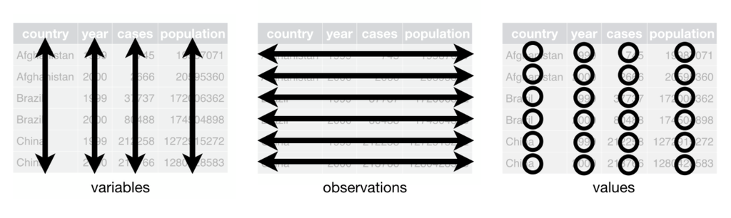

To plot the numerical data grouped by both the **Gene** and **Condition** attributes, we need to put each of these three “dimensions” into its own **column**.

This means we need to **transform** our data from a *wide* format to a *long* format:

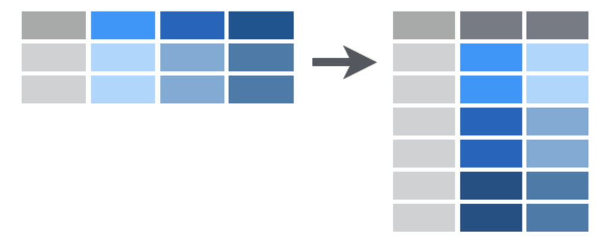

Long format

To do this we can use the `stack()` command. There are other commands to do this in the `tidyverse` package, which we will learn about later.

```r
# ================================================== #
# transform wide to long format


# ================================================== #
# Let's rename "ind" to "Condition"


# ================================================== #
# Let's also add a "Gene" column
# Since there are 5 genes and 3 conditions, we will just replicate the 5 gene names 3 times.
```

Now we can make our stacked and side-by-side bar plots.

```r
# ================================================== #
# stacked


# ================================================== #
# side-by-side
```

Next time, we will look at boxplots, violin plots, faceting, and placing multiple graphs on the same plot in the style of a figure in a publication.